# Getting started

Justin M Shea

# Introduction

The `neverhpfilter` package consists of 2 `functions`, 12 economic data sets, Robert Shiller’s U.S. Stock Market and CAPE Ratio data from 1871 through 2019, and a `data.frame` containing the original filter estimates found on table 2 of [Hamilton (2017) <doi:10.3386/w23429>.](https://www.nber.org/papers/w23429) All data objects are stored as `.Rdata` files in eXtensible Time Series (`xts`) format.

One of the first things to know about the `neverhpfilter` package is that it’s functions accept and output, `xts` objects.

An `xts` object is a `list` consisting of a `vector` index of some date/time class paired with a `matrix` object containing data of type `numeric`. `data.table` is also heavily used in finance and has efficient date/time indexing capabilities as well. It is useful when working with large data.frame like lists containing vectors of multiple data types of equal length. If using `data.table` or some other index based time series data object, merging the `xts` objects created by functions of this package should be fairly easy. Note `xts` is a dependency listed under the “Suggests” field of `data.table` DESCRIPTION file.

For more information on `xts` objects, go [here](https://CRAN.R-project.org/package=xts) and [here.](http://rstudio-pubs-static.s3.amazonaws.com/288218_117e183e74964557a5da4fc5902fc671.html)

## yth_glm

The `yth_glm` function wraps `glm` and primarily exists to model the output for the `yth_filter`. On that note, the function API allows one to use the `...` to pass any additional arguments to `glm`.

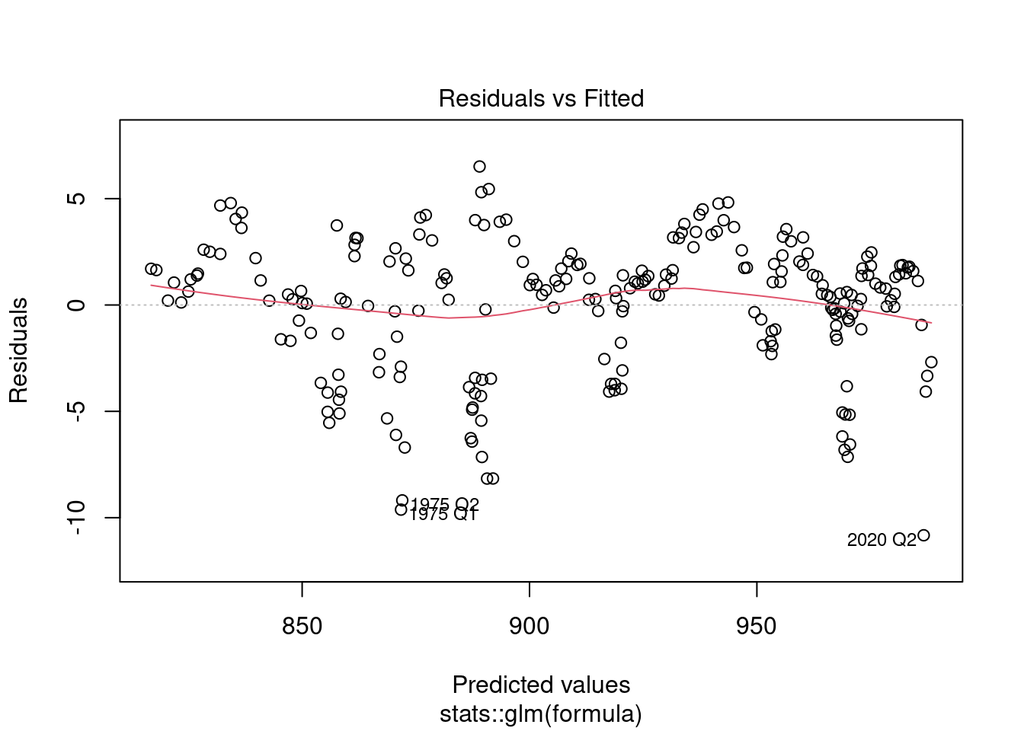

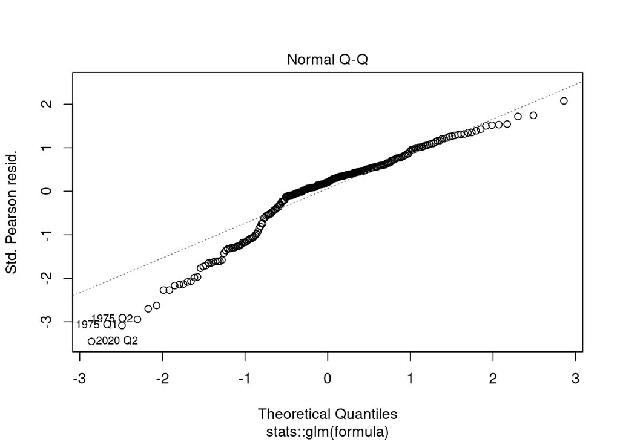

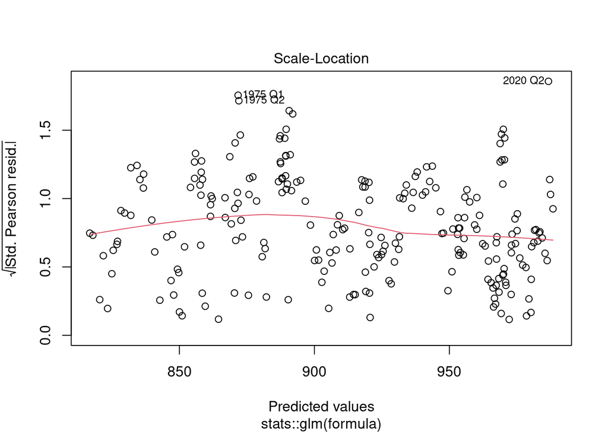

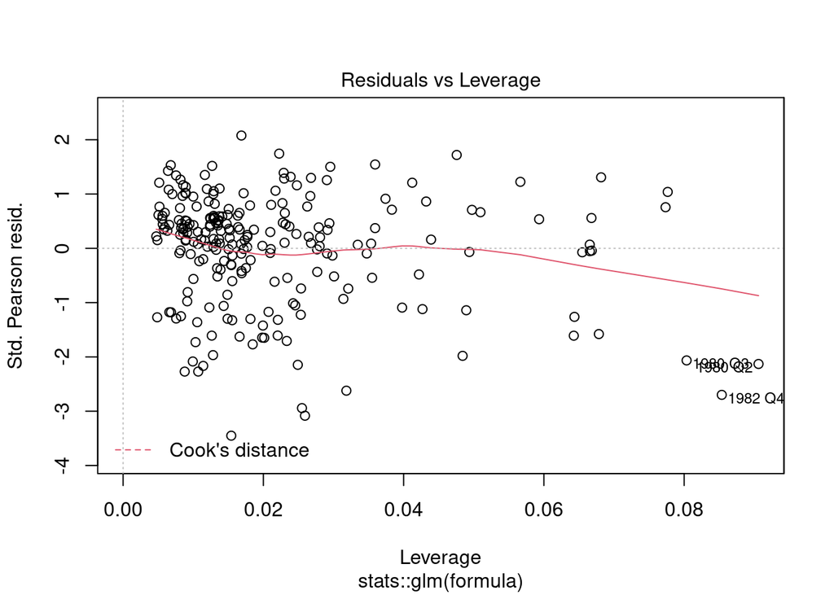

```r
library(neverhpfilter)

data(GDPC1)

log_RGDP <- 100*log(GDPC1)

gdp_model <- yth_glm(log_RGDP["1960/"], h = 8, p = 4)

plot(gdp_model)
```

## yth_filtered

This is the main function of the package. It both accepts and outputs `xts` objects. The resulting output contains various series discussed in Hamilton (2017). These are a user defined combination of the original, trend, cycle, and random walk series. See documentation and the original paper for further details.

```r
gdp_filtered <- yth_filter(log_RGDP, h = 8, p = 4)

tail(gdp_filtered, 16)
```

```
##            GDPC1 GDPC1.trend  GDPC1.cycle GDPC1.random
## 2017 Q2 980.1125    980.5180  -0.40546176    3.5587871
## 2017 Q3 980.8387    980.7418   0.09688729    3.9230290
## 2017 Q4 981.7899    980.9952   0.79471218    4.7139347
## 2018 Q1 982.7172    981.7481   0.96918064    5.0764851
## 2018 Q2 983.3836    982.0011   1.38255033    5.4314549
## 2018 Q3 983.9075    982.4911   1.41636940    5.4123565
## 2018 Q4 984.2352    983.1578   1.07740709    5.1128136
## 2019 Q1 984.9578    983.6123   1.34540590    5.2712447
## 2019 Q2 985.3278    983.9876   1.34017177    5.2152403
## 2019 Q3 985.9627    984.7926   1.17005752    5.1239448
## 2019 Q4 986.5472    985.7544   0.79275616    4.7573254
## 2020 Q1 985.2765    986.5266  -1.25013025    2.5592658
## 2020 Q2 975.8607    987.0648 -11.20410477   -7.5229496
## 2020 Q3 983.0730    987.6000  -4.52705206   -0.8344824
## 2020 Q4 984.1316    987.9872  -3.85561298   -0.1036844
## 2021 Q1 985.6793    988.8395  -3.16020404    0.7214990
```

```r
class(gdp_filtered)
```

```
## [1] "xts" "zoo"
```

As the output is an `xts` object, it inherits all generic methods associated with `xts`. For example, one can conveniently produce clean time series graphics with `plot.xts`.

Not the use of `xts::addPanel` function, which is used to panel plot the `cycle` component of the `yth_filter`.

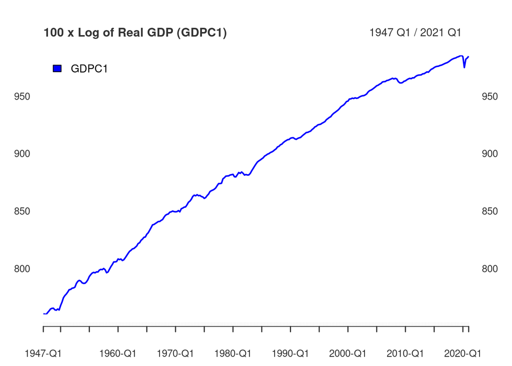

```r
plot(log_RGDP, grid.col = "white", col = "blue", legend.loc = "topleft", main = "100 x Log of Real GDP (GDPC1)")
```

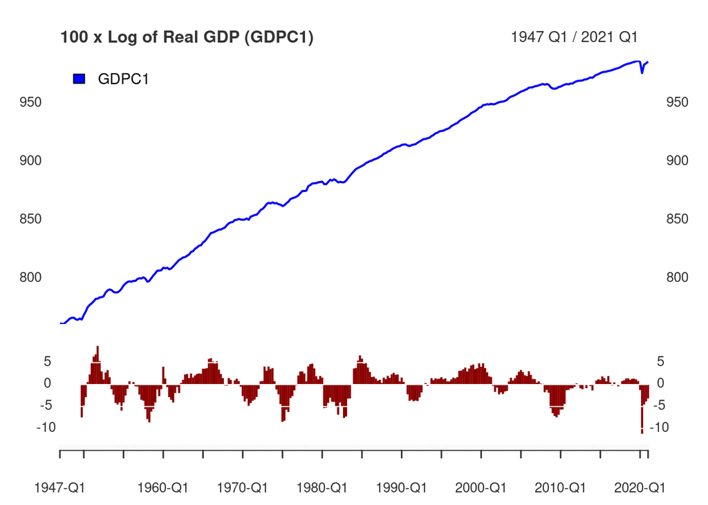

```r
addPanel(yth_filter, output=c("cycle"), type="h", on=NA, col="darkred" )
```

## Choices for h and p

In the original paper, Hamilton aggregates the `PAYEMS` monthly employment series into data of quarterly periodicity prior to apply his filter. That is a desirable approach when comparing with other economic series of quarterly periodicity. However, using the `yth_filter` function, one can choose to retain the monthly series and adjust the `h` and `p` parameters accordingly.

The default parameters of `h = 8` and `p = 4` assume times series data of a quarterly periodicity. For time series of monthly periodicity, one can retain the same look-ahead and lag periods with `h = 24` and `p = 12`. See the `yth_filter` documentation for more details.

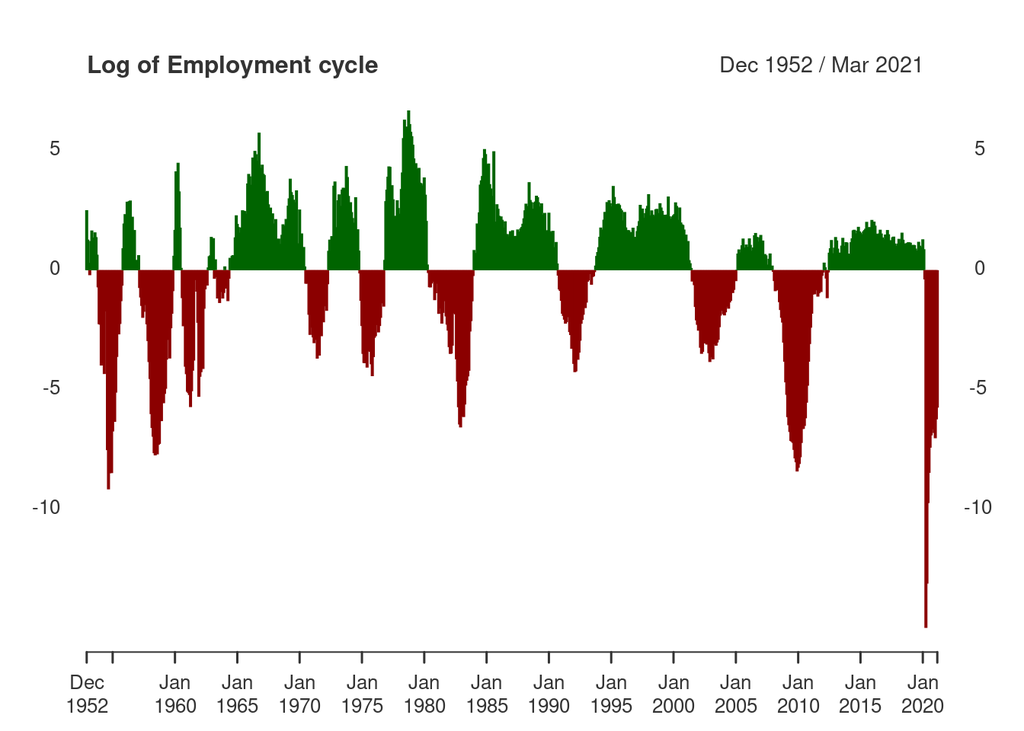

```r
Employment_log <- 100*log(PAYEMS["1950/"])

employment_cycle <- yth_filter(Employment_log, h = 24, p = 12, output = "cycle")

plot(employment_cycle, grid.col = "white", type = "h", up.col = "darkgreen", dn.col = "darkred",
     main = "Log of Employment cycle")
```

In addition to adjusting parameters to accommodate other periodicities, one may wish to explore longer term cycles by extending `h`. Below are examples of moving the look-ahead period defined by `h` from 8 quarters (2 years), to 20 quarters (5 years), and then 40 quarters (10 years).

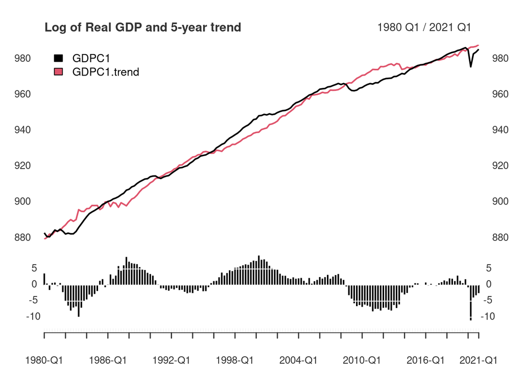

```r
gdp_5yr <- yth_filter(log_RGDP, h = 20, p = 4, output = c("x", "trend", "cycle"))

plot(gdp_5yr["1980/"][,1:2], grid.col = "white", legend.loc = "topleft",
     main = "Log of Real GDP and 5-year trend",
     panels = 'lines(gdp_5yr["1980/"][,3], type="h", on=NA)')
```

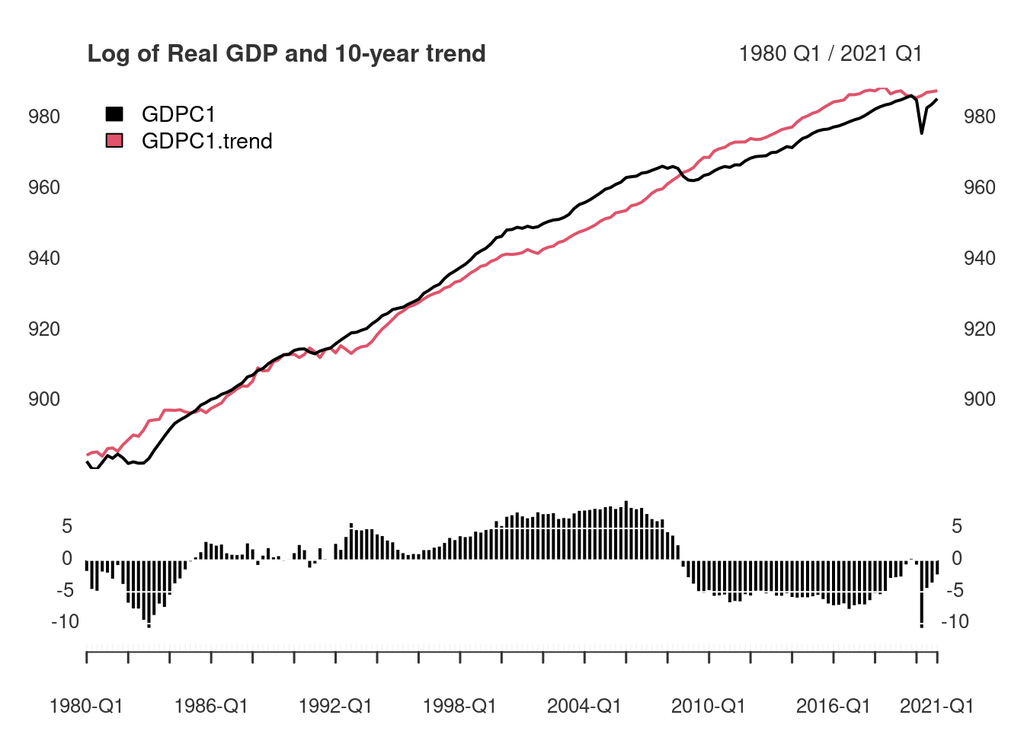

```r
gdp_10yr <- yth_filter(log_RGDP, h = 40, p = 4, output = c("x", "trend", "cycle"))

plot(gdp_10yr["1980/"][,1:2], grid.col = "white", legend.loc = "topleft",
     main = "Log of Real GDP and 10-year trend",
     panels = 'lines(gdp_10yr["1980/"][,3], type="h", on=NA)')
```

## Conclusion

These functions give you an avenue to filter econometric time series into `trend` and `cycle` components. They identify a more stable trend and cycle components that doesn’t have the estimation issues associated with the `head` and `tail` portions of those generated by the HP-filter.